# Lab 2

Analyzing Australian Bushfires Using Tidyverse

Varun Goel

1/27/2020

# 1 Summary

In this Lab, you will use introductory yet powerful tidyverse commands to analyze a current real world dataset of Australian Bushfires. This huge and messy dataset has already been cleaned for you, and the focus of this lab will be to apply and solidify what you have learnt in your data camp modules. In addition, the purpose of this lab is to push you and provide you practice in interpreting, communicating and publishing your analysis in a readable and reproducible way

*Replace the summary text with 3-5 sentences about what you learn about the current Australian Bushfires from this analysis. Complete this step after you finish the lab analysis*

# 2 Preparations

First of all, as we learnt in lab1, we cant to create an R project for lab2 to keep all our code together. As we did earlier in lab1, either create a project in a new directory called *lab2* or create a directory called lab2 and and create the project in an existing directory. If you dont remember, you can get a [refresher on projects](https://r4ds.had.co.nz/workflow-projects.html). Section 8.4 has the instructions on how to create a new project.

Before you start working in RMarkdown, you need to make sure you have the necessary R packages installed:

**Run the R code in your console to install the “rmarkdown” and “tidyverse”. Remove the check_packages chunk once your packages are installed.**

```r
# This code will install required packages if they are not already installed
# ALWAYS INSTALL YOUR PACKAGES LIKE THIS!
packageList <- c("rmarkdown","tidyverse")
for(p in packageList){
  if (!requireNamespace(p)) {
    install.packages(p)
  }
}
```

Now, load your relevant R packages

**In the following chunk (load_packages), avoid printing the messages about attachments and conflicts by setting the chunk options `message` and `warnings` to `FALSE`. This has already been done for you in the check_packages chunk. You can replicate the same for the load_packages chunk**

```r
library(readr)
library(magrittr)
library(ggplot2)
library(tidyr)
library(dplyr)
```

# 3 Analysis

## 3.1 Data

Now, you will import the Bushfire data using the read_csv() function. read_csv() is a tidyverse function do import the data, that is smarter and faster than the base R read.csv() function. Here, you will read the directly from a website address, also called a *URL* (Universal record locator)

```r
fires_raw <- read_csv("https://geog215-spds.rbind.io/labs/lab2/aus_fires.csv")
```

Now that your data is loaded, the next step is to get familiarized with the data. In the following code chunk type in the commands for the following?

- **Use the tidyverse function `glimpse()` to get a peak at your data. This is just like the `str()` function but neater and shows you more data**
- **Use the print() function to take a look at the first few rows of your data and see how it is arranged** (The syntax is just like str() or summary(), you give the dataframe as the argument inside the function)
- **Use the summary() function to look at basic statistics and any flaws in the dataset**

```r
glimpse(fires_raw)
```

```
## Observations: 2,118
## Variables: 7
## $ year        <dbl> 1990, 1990, 1990, 1990, 1990, 1990, 1990, 1990, 1990, 199…
## $ month       <dbl> 1, 2, 3, 4, 5, 6, 7, 8, 9, 10, 11, 12, 1, 2, 3, 4, 5, 6, …
## $ temp_max    <dbl> 27.06452, 25.60893, 26.50645, 22.66667, 20.21935, 16.0950…
## $ state_name  <chr> "South Australia", "South Australia", "South Australia", …
## $ rainfall_mm <dbl> 29.2, 4.4, 0.5, 11.6, 13.2, 83.0, 96.4, 91.4, 49.5, 28.6,…
## $ n_fires     <dbl> NA, NA, NA, NA, NA, NA, NA, NA, NA, NA, NA, NA, NA, NA, N…
## $ temp_mean   <dbl> 21.82097, 20.85539, 21.41371, 17.83167, 15.86694, 12.1483…
```

```r
print(fires_raw)
```

```
## # A tibble: 2,118 x 7
##     year month temp_max state_name      rainfall_mm n_fires temp_mean
##    <dbl> <dbl>    <dbl> <chr>                 <dbl>   <dbl>     <dbl>
##  1  1990     1     27.1 South Australia        29.2      NA      21.8
##  2  1990     2     25.6 South Australia         4.4      NA      20.9
##  3  1990     3     26.5 South Australia         0.5      NA      21.4
##  4  1990     4     22.7 South Australia        11.6      NA      17.8
##  5  1990     5     20.2 South Australia        13.2      NA      15.9
##  6  1990     6     16.1 South Australia        83        NA      12.1
##  7  1990     7     15.3 South Australia        96.4      NA      11.6
##  8  1990     8     14.9 South Australia        91.4      NA      11.4
##  9  1990     9     19.3 South Australia        49.5      NA      14.5
## 10  1990    10     21.5 South Australia        28.6      NA      16.4
## # … with 2,108 more rows
```

```r
summary(fires_raw)
```

```
##       year          month          temp_max       state_name
##  Min.   :1990   Min.   : 1.00   Min.   : 9.745   Length:2118
##  1st Qu.:1997   1st Qu.: 3.00   1st Qu.:19.078   Class :character
##  Median :2004   Median : 6.00   Median :23.110   Mode  :character
##  Mean   :2004   Mean   : 6.45   Mean   :22.729
##  3rd Qu.:2012   3rd Qu.: 9.00   3rd Qu.:26.427
##  Max.   :2019   Max.   :12.00   Max.   :35.624
##
##   rainfall_mm        n_fires         temp_mean
##  Min.   :  0.00   Min.   :   1.0   Min.   : 4.784
##  1st Qu.: 20.18   1st Qu.:  12.0   1st Qu.:13.985
##  Median : 44.30   Median :  63.5   Median :17.590
##  Mean   : 60.83   Mean   : 355.4   Mean   :17.428
##  3rd Qu.: 79.05   3rd Qu.: 278.2   3rd Qu.:21.143
##  Max.   :949.20   Max.   :9591.0   Max.   :27.866
##  NA's   :686      NA's   :1218
```

Based on your observations, answer the following:

- **What is the data type for `state_name` ? Would this have been different if you would have typed `read.csv()` instead?**
- **By looking at the output of print, do any red flags about the data prop up? You will notice the first line of print mentions that this data is a `tibble`. Tibbles are basically the same as data frames but they print more nicely and play well with tidyverse commands.**

-**By looking at the output of the summary command, write a small paragraph about the data. Importantly, mention what the data is measuring (the 3 variables and the frequency of each observation), time range of the whole data, and what columns, if any have any missing values**.

- *Tip: you will notice that summary of `state_name` does not really tell us anything. In this case, storing them as factors may have given us more information about the different number of states. But we will revisit this later.*

-**Based on the summary, mention the highest maximum temperature and highest rainfall. Extra credit if you can provide the number by using an inline r markdown command.

## 3.2 Check for missing data on Bushfires

You will now use some data wrangling commands to unearth what is going on with missing values. Dealing with missing values is important and sometimes complicated. What we want to make sure is that we understand why data is missing, and deal with it accordingly. For example, in some cases, missing data may be missing because the values actually dont exist, or it may just be a placeholder for 0. Therefore, it is *very* important to distinguish *truly missing* data from data that is *just missing a value*. Deleting all rows with some missing data can result in loss of useful information and give biased results.

Time to wield your detective lens and wrangle with the data:

Lets take a look at the missing values in the `n_fires` column that contains the number of recorded bushfires for each month.

**In the code chunk below, first calculate the proportion of missing values for each year. As you learned in datacamp, you can do this by taking the dataset and `group_by()` year, `summarize()` the number of NAs for each year, `mutate` a new column called `perc_NA` that calculates the percentage of NAs in each year, and then `arrange()` by decreasing order based on percentage of missing bushfires.** (Some of the code is already done for you)

**We will take a look at the data using the `print` command**

```r
perc_missing_fires <- fires_raw %>% group_by(year) %>%
  summarize(total_na = sum(is.na(n_fires)),
            total_observations = n()) %>% # n() calculates total observations by group (in this case, year)
  mutate(perc_na = total_na/total_observations*100) %>%
  arrange(desc(perc_na))

print(perc_missing_fires)
```

```
## # A tibble: 30 x 4
##     year total_na total_observations perc_na
##    <dbl>    <int>              <int>   <dbl>
##  1  1990       72                 72     100
##  2  1991       72                 72     100
##  3  1992       72                 72     100
##  4  1993       72                 72     100
##  5  1994       72                 72     100
##  6  1995       72                 72     100
##  7  1996       72                 72     100
##  8  1997       72                 72     100
##  9  1998       72                 72     100
## 10  1999       72                 72     100
## # … with 20 more rows
```

**By glancing at the printed output, are there any years with 100% missing values? Luckily, we know the reason why. The data documentation tells us that the years the fires started getting recorded by satellite. Go to https://firms.modaps.eosdis.nasa.gov/download/, check the Temporal coverage for *MODIS Collection 6* and explain when the coverage started**.

Now, that we know the cause of the missingness, we can create a clean bushfires data by using `filter()` to remove years with 100 % missing bushfires data.

```r
# first we need to know what years are completely missing
# you can subset using what you learnt in lab1 as displayed here
years_missing100 <- perc_missing_fires$year[perc_missing_fires$perc_na == 100]
## A tidyverse way of doing this is below: it is more readable
years_missing100 <- perc_missing_fires %>% filter(perc_na == 100) %>%
  .$year
# Now we can filter only those that are NOT in 100% missing years: remember filter() equates to subsetting.
# %in% is a very useful operator that tells you to whether year is "in" any of the values of years stored in the years_missing100 vector.
# Also, since the the "Australian Capital Territory" does not have many fires , we will remove that from analysis too.
fires_noNa <- fires_raw %>% filter(!(year %in% years_missing100)) %>%
  filter(state_name !="Australian Capital Territory")

## check if there are any more missing values
is.na(fires_noNa$n_fires) %>% sum() %>% cat("There are", ., "missing n_fires values")
```

```
## There are 97 missing n_fires values
```

** Arghhhhh, we are not done yet. There are still missing values, but the good news is that since we know the data was collected from 2003 onwards, these values show that no Bushfires were detected during the missing value months. Let’s replace the remaining `NAs` with `0`.

```r
# The tidyr package in tidyverse has a handy replace_NA function
fires_noNa$n_fires <- fires_noNa$n_fires %>% replace_na(0)

## check if there are any more missing values
is.na(fires_noNa$n_fires) %>% sum() %>% cat("There are", ., "missing n_fires values")
```

```
## There are 0 missing n_fires values
```

Woohoo! no more missing values, we are all set to move to the fun part: *Explorations and Visualizations* and *Visualizations*

## 3.3 Where and When?

Based on the data from 2003-2019 (already stored in `fires_noNa`), type code to answer the following: (Some of the code is already written to help aid you, while you fill in the blanks)

**What were the worst 5 years (in descending order from worst to least worst) for bushfires? Do you see any trend? Have fires have increased with time, decreased or stayed the same?**

```r
fires_noNa %>% group_by(year) %>%
  summarize(fires = sum(n_fires)) %>%
  arrange(desc(fires)) %>% top_n(n=5)
```

```
## # A tibble: 5 x 2
##    year fires
##   <dbl> <dbl>
## 1  2012 45576
## 2  2006 27026
## 3  2018 24532
## 4  2011 23838
## 5  2009 20897
```

**Which months are the worst for fires based on the whole data? Show top 3 months and the number of fires**

```r
fires_noNa %>% group_by(month) %>%
  summarize(fires = sum(n_fires)) %>%
  arrange(desc(fires)) %>% top_n(n=3)
```

```
## # A tibble: 3 x 2
##   month fires
##   <dbl> <dbl>
## 1    11 77612
## 2    10 70902
## 3    12 40044
```

**Which states are the worst hit? Arrange (in ascending order) the states with the highest number of fires across the whole time period**

```r
fires_noNa %>% group_by(state_name) %>%
  summarize(fires = sum(n_fires)) %>%
  arrange(fires)
```

```
## # A tibble: 5 x 2
##   state_name         fires
##   <chr>              <dbl>
## 1 South Australia     5554
## 2 Victoria           14578
## 3 New South Wales    15899
## 4 Queensland        120194
## 5 Western Australia 163158
```

**When and where was the worst period (defined as the month and year) for fires in Australia? Note: the answer will be 1 row containing the state_name, month, year and n_fires**

```r
fires_noNa %>% select(state_name,month,year,n_fires) %>%
  arrange(n_fires) %>% top_n(n=1)
```

```
## # A tibble: 1 x 4
##   state_name        month  year n_fires
##   <chr>             <dbl> <dbl>   <dbl>
## 1 Western Australia    10  2012    9591
```

**(EXTRA CREDIT CHALLENGE) What were the top 10 worst periods? This is important as it helps us gauge whether a disaster is part of a cycle, or an anomaly, and helps inform disaster management response. Your output will be 10 rows: state_name, month, year and n_fires arranged by time(from latest to earliest). Does the severity of the fires increase/decrease with time or is there no clear pattern? What months do the worst disasters generally take place in? What states are most effected?**

```r
fires_noNa %>% select(state_name,month,year,n_fires) %>%
  arrange(n_fires) %>% top_n(n=10) %>% arrange(desc(year,month))
```

```
## # A tibble: 10 x 4
##    state_name        month  year n_fires
##    <chr>             <dbl> <dbl>   <dbl>
##  1 Western Australia    10  2018    4912
##  2 Western Australia    11  2017    5198
##  3 Western Australia    11  2012    5422
##  4 Queensland           12  2012    5557
##  5 Queensland           11  2012    5835
##  6 Western Australia    10  2012    9591
##  7 Queensland           11  2011    4147
##  8 Queensland           10  2011    5101
##  9 Queensland           11  2009    4381
## 10 Western Australia    11  2006    5699
```

## 3.4 Visualize Bushfires

### 3.4.1 Histograms of Bushfires

In summary, histograms visualize how your data is distributed. and help you understand the shape of your data distribution. We will cover them in detail in later lectures, but for now, take a look at the graph below:

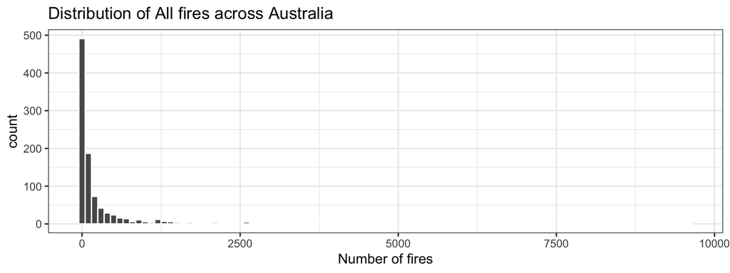

```r
fires_noNa %>% ggplot() +
  geom_histogram(aes(x = n_fires), binwidth = 100, col = "white") +
  xlab("Number of fires") +
  ggtitle("Distribution of All fires across Australia") +
  theme_bw()
```

The graph does not really tell us much except that the majority of months have low or no bushfires. However, there are certain months that have a large number of fires, with some having as many as 10000 fires. (The outliers are not clear visually in the graph, but they do exist)

Next, we can easily view this histograms for each state in a nice comparable graph using the facet_wrap() function as shown below.

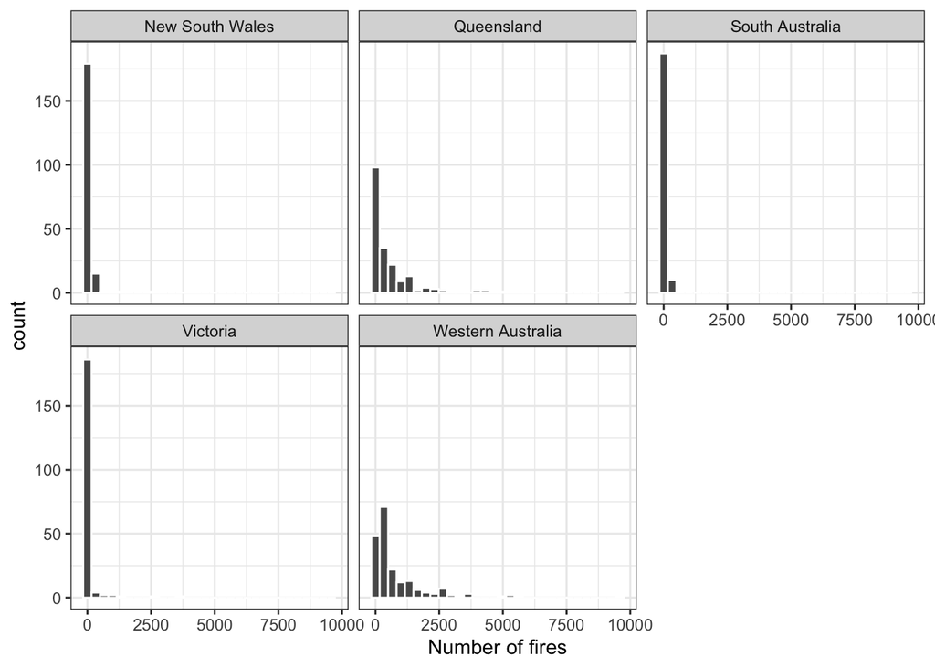

```r
fires_noNa %>% ggplot() +
  geom_histogram(aes(x = n_fires), col = "white") + facet_wrap(~state_name) +
  xlab("Number of fires") +
  theme_bw()
```

**Using the histogram can you deduce which state might have more severe fires as compared with another? In 1 line explain the difference in severity of fires between Queensland and Victoria, if any) There is no wrong answer here, this is just to get you thinking. You will get points for your explanation as long as it is earnest**

### 3.4.2 Bar Plots

Now, lets try plotting Bar plots

The amazing part about piping is that you can transform your data *on the fly* and feed it to the `ggplot()` using piping. Dont worry, this lab will not test you on that, but this is something useful to know for later.

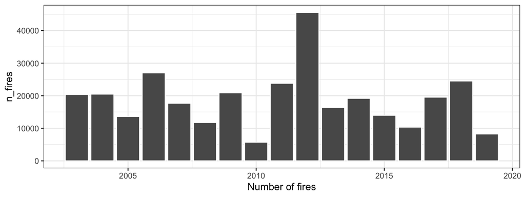

```r
fires_noNa %>% group_by(year) %>%
  summarize(n_fires = sum(n_fires)) %>%
  ungroup() %>%
  ggplot() +
  geom_bar(aes(x = year,y=n_fires), stat="identity", col = "white") +
  xlab("Number of fires") +
  theme_bw()
```

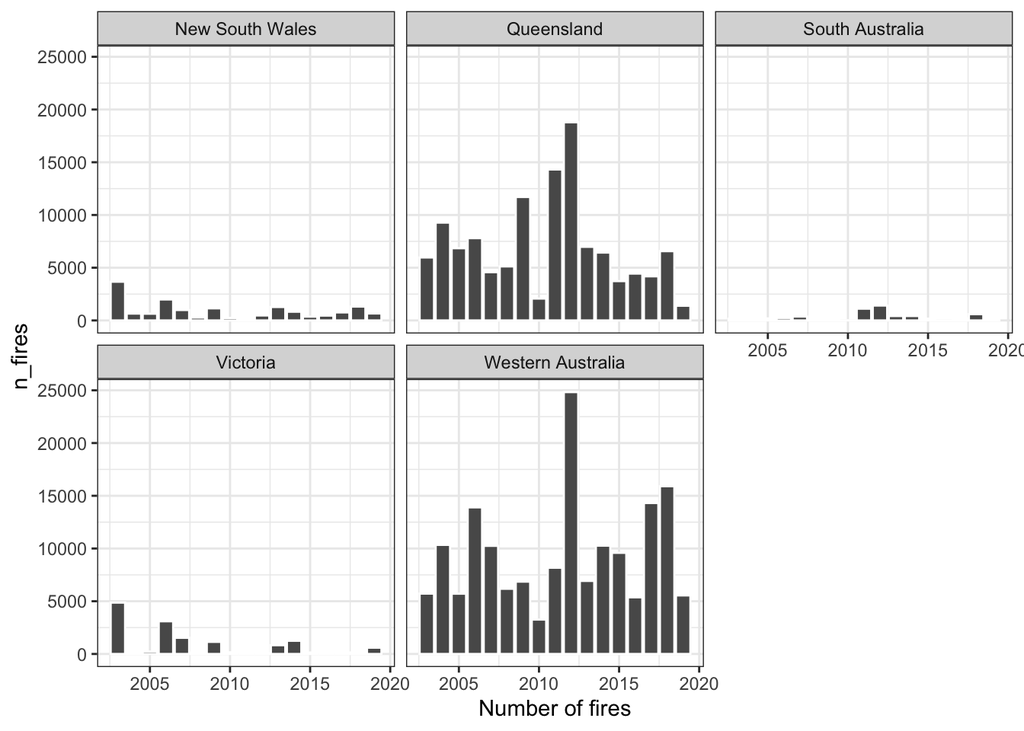

```r
fires_noNa %>% group_by(state_name,year) %>%
  summarize(n_fires = sum(n_fires)) %>%
  ungroup() %>%
  ggplot() +
  geom_bar(aes(x = year,y=n_fires), stat="identity", col = "white") +
  facet_wrap(~state_name) +
  xlab("Number of fires") +
  theme_bw()
```

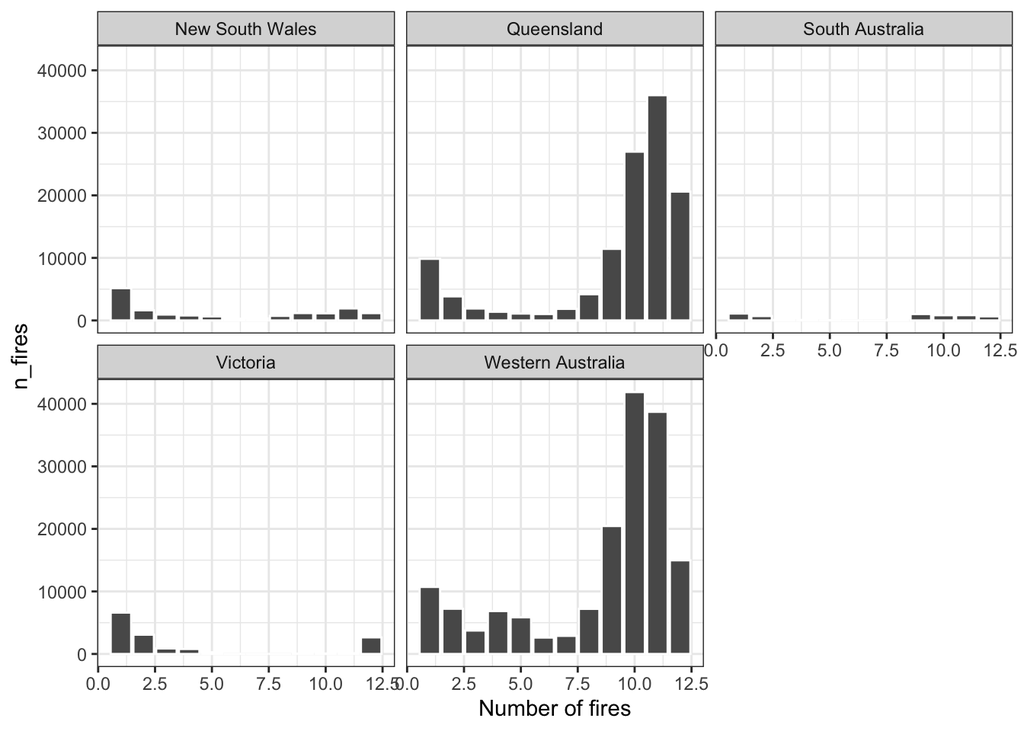

```r
fires_noNa %>% group_by(state_name,month) %>%
  summarize(n_fires = sum(n_fires)) %>%
  ungroup() %>%
  ggplot() +
  geom_bar(aes(x = month,y=n_fires), stat="identity", col = "white") +
  facet_wrap(~state_name) +
  xlab("Number of fires") +
  theme_bw()
```

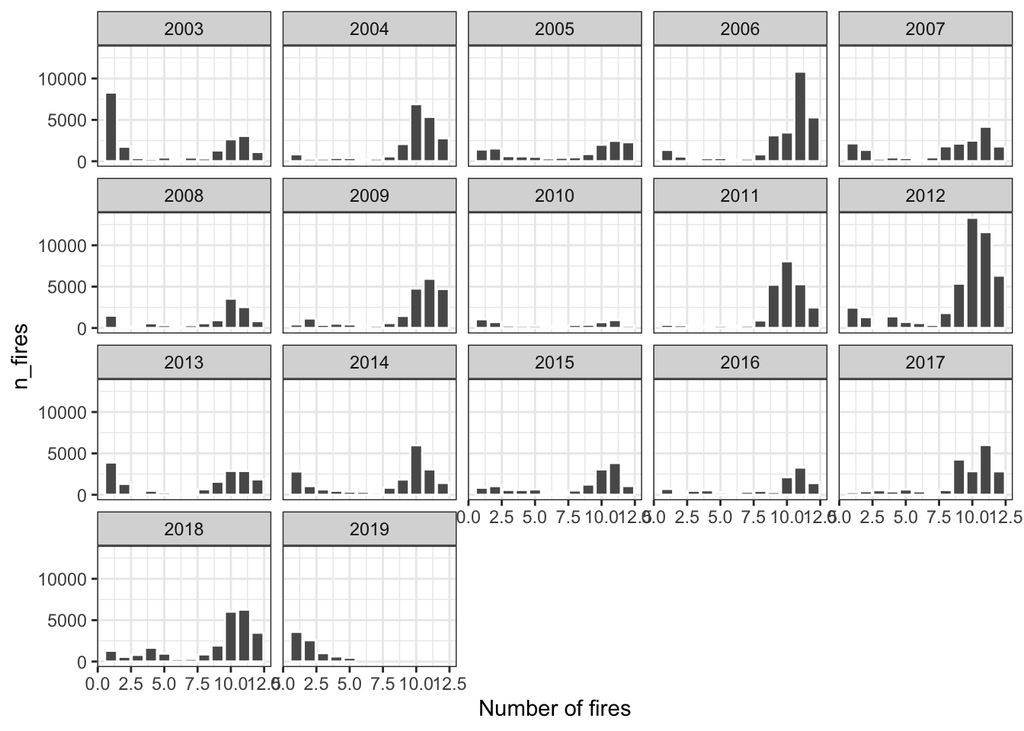

```r
fires_noNa %>% group_by(year,month) %>%
  summarize(n_fires = sum(n_fires)) %>%
  ungroup() %>%
  ggplot() +
  geom_bar(aes(x = month,y=n_fires), stat="identity", col = "white") +
  facet_wrap(~year) +
  xlab("Number of fires") +
  theme_bw()
```

### Scatter plots

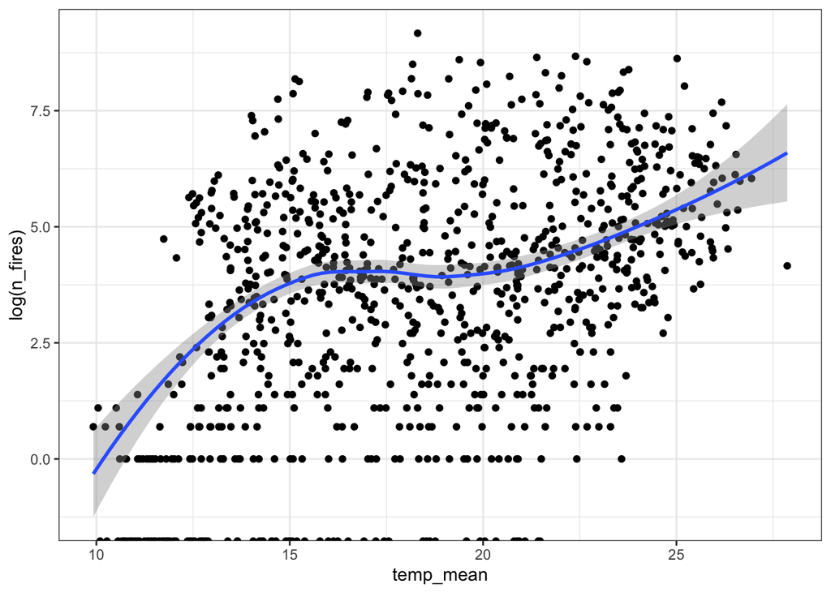

```r
fires_noNa %>%
  ggplot(aes(y = log(n_fires),x=temp_mean)) +
  geom_point() + geom_smooth() +
  theme_bw()
```

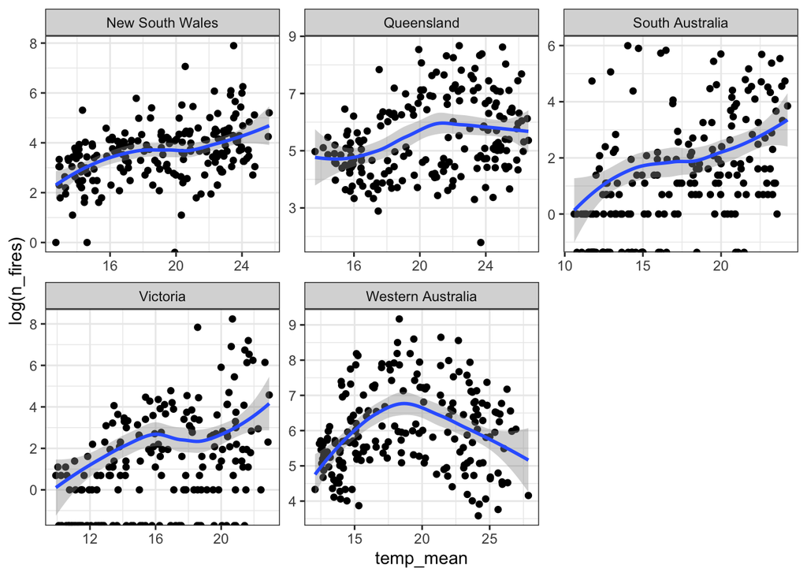

```r
fires_noNa %>%
  ggplot(aes(y = log(n_fires),x=temp_mean)) +
  geom_point() + geom_smooth() + facet_wrap(~state_name, scales = "free") +
  theme_bw()
```

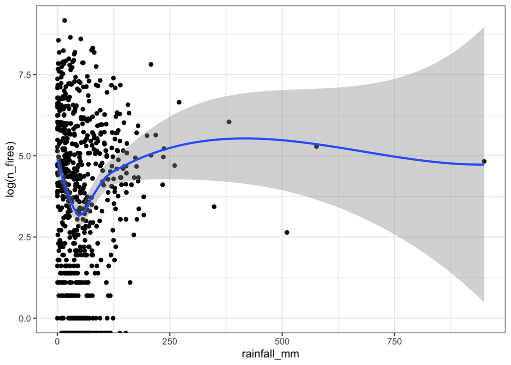

```r
fires_noNa %>%
  ggplot(aes(y = log(n_fires),x=rainfall_mm)) +
  geom_point() + geom_smooth() +
  theme_bw()
```

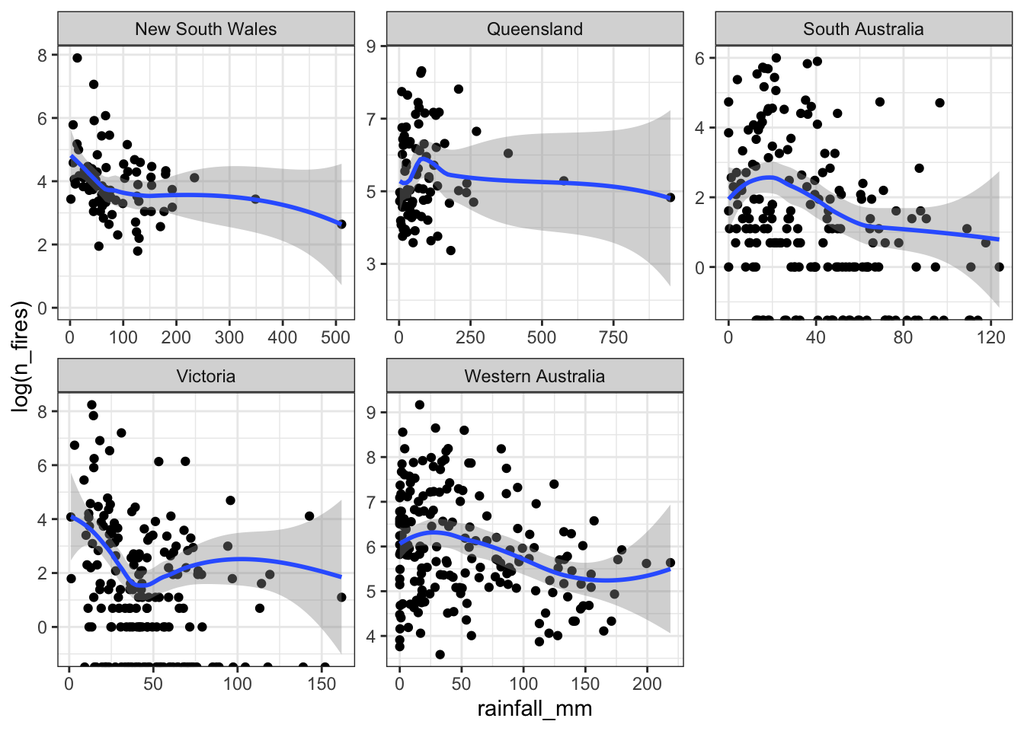

```r
fires_noNa %>%
  ggplot(aes(y = log(n_fires),x=rainfall_mm)) +
  geom_point() + geom_smooth() + facet_wrap(~state_name, scales = "free") +
  theme_bw()
```

## 3.5 Results